# Pitchfx_angels

Daniel Kost-Stephenson

March 21, 2016

# Visualizations

The first plot shows the total pitch movement by type for each appearance. We can observe that the pitcher’s changeup, four seam fastball and two seam fastball have less total movement on them in the later appearances (5-8). His slider actually had more movement in the later appearances but it didn’t seem to affect his pitch selection.

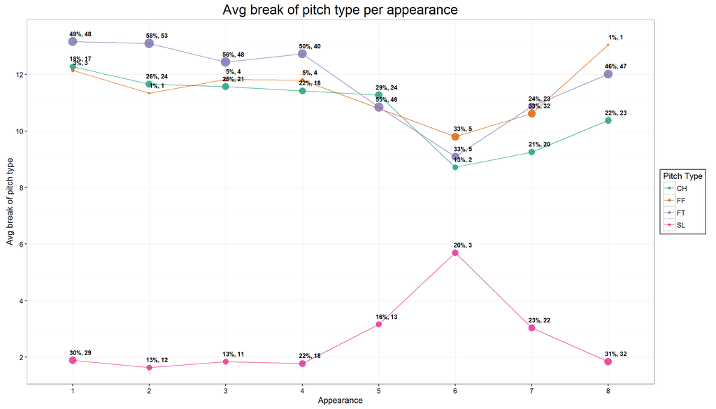

The next plot shows a density plot and boxplot of the velocity of each different pitch during each appearance (the number above is the mean velocity for that appearance). There seems to be a slight decrease in velocity in all his pitches in the later appearances as well as a slight increase in the variability of the velocity for each pitch type.

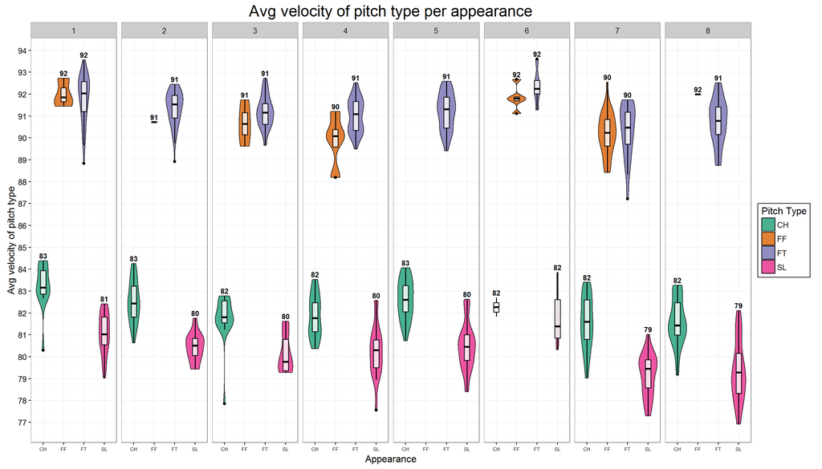

The last plot shows the trajectory of each pitch type for each appearance. The cluster at the bottom right represents the pitcher’s release point, and the other points represent the position of those pitch types after they broke. His changeup, four seam fastballs and two seam fastballs generally had less bite in later appearances (especially 5-7). Another interesting observation is that the break of his slider changes in later appearances (the cluster is shifted to the right). With less movement and a decrease in velocity, opposition swinging strike percentage could drop, the pitchers strike out rate would likely decrease and batters might make harder contact and drive the ball further.

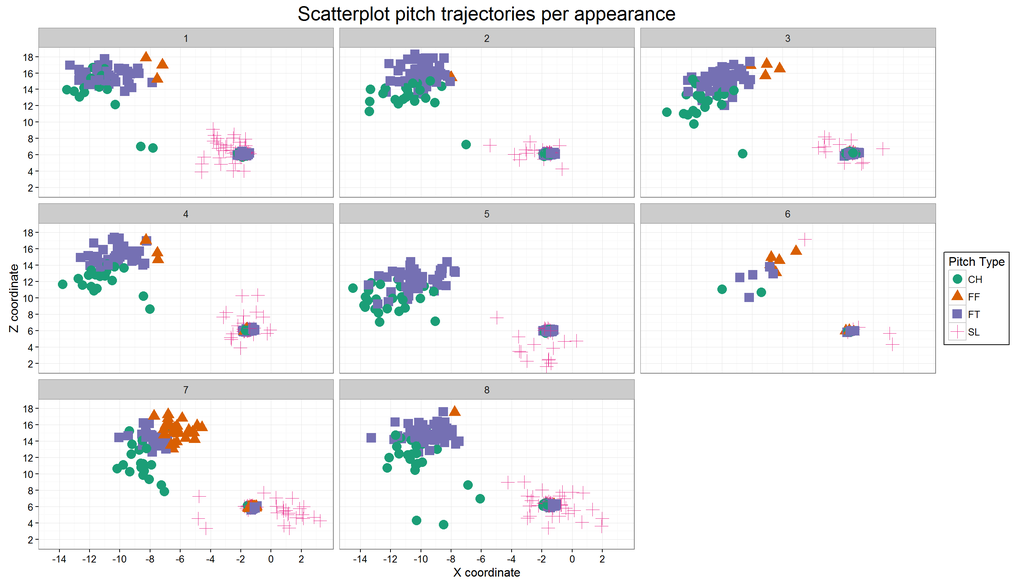